# Airway RNA-Seq: Reproduzierbare Datenanalyse - Gruppe 1

Autor:in

Michele Brömme, Felix Kieborz, Emily Komfort, Felix Meyer, Rebecca Schreck

# 1 Einleitung

Im Rahmen dieses Projekts wird der RNA-Seq-Datensatz `airway` aus dem Bioconductor-Paket `airway` untersucht. Der Datensatz umfasst acht Proben aus vier primären humanen Airway-Smooth-Muscle-Zelllinien. Für jede Zelllinie liegt jeweils eine unbehandelte Probe (`untrt`) und eine mit Dexamethason behandelte Probe (`trt`) vor. Der zugrunde liegende Datensatz ist dem PLOS-ONE-Beitrag mit der DOI `10.1371/journal.pone.0099625` zugeordnet.

Ziel der Analyse ist es, die Daten zunächst in eine konsistente und auswertbare Form zu überführen, ihre Qualität zu untersuchen und Low-Count-Gene zu filtern. Anschließend werden die Daten normalisiert und varianzstabilisiert. Darauf aufbauend werden Unterschiede zwischen behandelten und unbehandelten Proben mittels Differential-Expression-Analyse untersucht. Ergänzend werden PCA, t-SNE und UMAP zur explorativen Dimensionsreduktion sowie verschiedene Clustering-Verfahren eingesetzt, um zu prüfen, ob sich eine Dexamethason-assoziierte Struktur auch ohne vorgegebene Gruppenzuordnung erkennen lässt.

# 2 Data Wrangling

Der Datensatz liegt zunächst als Bioconductor-Objekt vor. Um die Informationen für die nachfolgenden Analyseschritte nutzbar zu machen, werden Messwerte, Probeninformationen und Geninformationen zunächst getrennt betrachtet und anschließend in einer gemeinsamen Tabelle zusammengeführt.

Die Messwerte werden dazu aus dem Wide- in das Long-Format überführt. Die Probeninformationen werden über die Sample-ID (`sample` bzw. `Run`) zugeordnet, während die Geninformationen über die `gene_id` ergänzt werden. Dadurch entsteht mit `Daten_roh_long` eine gemeinsame Tabelle, die Counts, Sample-Metadaten und Genannotation enthält. Abschließend wird überprüft, ob die erwartete Anzahl an Proben und Genen vorliegt und ob fehlende Werte oder strukturelle Auffälligkeiten vorhanden sind.

```r
#1. Datenstruktur verstehen:

airway

assay(airway)

colData(airway)

head(assay(airway))

dim(airway)

#2. Datenextraktion

Messwerte_roh <- assay(airway)

Probeninformationen <- as.data.frame(colData(airway))

Geninformationen <- as.data.frame(rowData(airway))

#3. Untersuchung Messwerte_roh,Probeninformationen, Geninformationen

class(Messwerte_roh)
dim(Messwerte_roh)
head(Messwerte_roh)
colnames(Messwerte_roh)
rownames(Messwerte_roh)

class(Probeninformationen)
dim(Probeninformationen)
head(Probeninformationen)
colnames(Probeninformationen)
rownames(Probeninformationen)

class(Geninformationen)
dim(Geninformationen)
head(Geninformationen)
colnames(Geninformationen)
rownames(Geninformationen)

#4. Überprüfung gleicher Sample-IDs

all(colnames(Messwerte_roh) == Probeninformationen$Run)

#5. Erstellen einer Probeninformationstabelle

Tab_Probeninformationen <- Probeninformationen[, c(
  "Run",
  "cell",
  "dex",
  "avgLength"
)]

#6. Überprüfung erstellter Tabelle

nrow(Tab_Probeninformationen)

length(unique(Tab_Probeninformationen$Run))

#7. Messwerte_roh ins Long Format bringen

Messwerte_roh_long <- as.data.frame(Messwerte_roh)

Messwerte_roh_long$gene_id <- rownames(Messwerte_roh_long)

rownames(Messwerte_roh_long) <- NULL

Messwerte_roh_long <- pivot_longer(
  Messwerte_roh_long,
  col = -gene_id,
  names_to ="sample",
  values_to = "counts"

)

#8. Überprüfung der Tabelle

dim(Messwerte_roh_long)

#9. Messwerte_roh_long mit Tab_Probeninformationen verbinden

Daten_roh_long <- Messwerte_roh_long %>%
  left_join(
    Tab_Probeninformationen,
    by = c("sample" = "Run")
  )

#10. Neue Tabelle überprüfen

head(Daten_roh_long)

dim(Daten_roh_long)

sum(is.na(Daten_roh_long$cell))


#11. Join von Daten_roh_long und Geninformationen

Daten_roh_long <- Daten_roh_long %>%
  left_join(
    Geninformationen,
    by = "gene_id"
  )

#12. Überprüfung des Daten_roh_long-Datensatzes

##Aufbau der Rohdatentabelle

glimpse(Daten_roh_long)

##Anzahl der Proben

n_distinct(Daten_roh_long$sample)

##Anzahl der Gene

n_distinct(Daten_roh_long$gene_id)

##Anzahl der Gene pro Probe

Daten_roh_long %>%
  count(sample)

##Verteilung der Genprobendaten auf treated und untreated

Daten_roh_long %>%
  count(dex)

##Anzahl Genprobendaten pro Zelllinie

Daten_roh_long %>%
  count(cell, dex)

##Suche nach NA-Werten

colSums(is.na(Daten_roh_long))

#13. Rohdatentabelle als csv speichern

write.csv(
  Daten_roh_long,
  "data/Daten_roh_long.csv",
  row.names = FALSE
)
```

# 3 Quality Assessment und Quality Control

## 3.1 Quality Assessment

Im Quality Assessment (QA) wird die Datenqualität zunächst diagnostisch untersucht, ohne die Daten unmittelbar zu verändern. Dazu werden die Datenstruktur, mögliche Duplikate und fehlende Werte kontrolliert. Anschließend wird eine Gene-×-Sample-Count-Matrix erzeugt, auf deren Grundlage mehrere Qualitätsmerkmale betrachtet werden.

### 3.1.1 Library Size

Für jedes Sample wird die Summe aller Counts bestimmt. Unterschiede in der Library Size weisen auf unterschiedliche Sequenziertiefen hin und begründen die Notwendigkeit einer späteren Normalisierung. Im vorliegenden Datensatz weist `SRR1039513` die geringste und `SRR1039517` die größte Library Size auf.

```r
# 1. Welche Daten verwendet werden

data <- Daten_roh_long


# 2. KONTROLLE DER DATENSTRUKTUR

str(data)

head(data)

dim(data)

colnames(data)


# Anzahl NA-Werte pro Variable

colSums(is.na(data))

# Gesamtzahl der NA-Werte

sum(is.na(data))


# Duplikate?

sum(
  duplicated(
    data[, c("gene_id", "sample")]
  )
)


# sample/gen anzahl
length(unique(data$sample))

length(unique(data$gene_id))

unique(data$sample)

unique(data$cell)

unique(data$dex)


# Hier startet die QA


# 3. Count-Matrix

count_data <- data %>%
  select(
    gene_id,
    sample,
    counts
  ) %>%
  pivot_wider(
    names_from = sample,
    values_from = counts
  )

count_data <- as.data.frame(count_data)

rownames(count_data) <- count_data$gene_id

count_data$gene_id <- NULL

count_matrix <- as.matrix(count_data)


# Kontrolle

dim(count_matrix)

head(count_matrix)
```

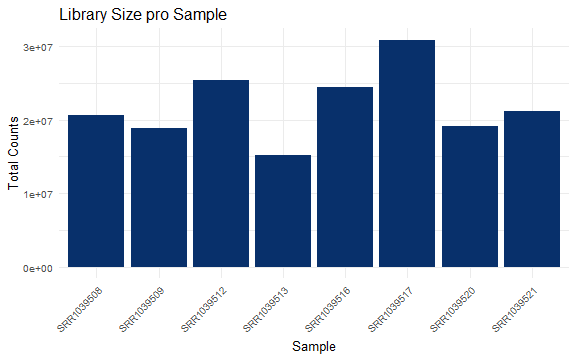

Library Size der acht Airway-Proben.

```r
# 4. Library size

library_size <- colSums(count_matrix)

library_size_df <- data.frame(
  sample = names(library_size),
  total_counts = as.numeric(library_size)
)

ggplot(
  library_size_df,
  aes(
    x = sample,
    y = total_counts
  )
) +
  geom_col(
    fill = "#08306B"
  ) +
  labs(
    title = "Library Size pro Sample",
    x = "Sample",
    y = "Total Counts"
  ) +
  theme_minimal(base_size = 13) +
  theme(
    axis.text.x = element_text(
      angle = 45,
      hjust = 1
    )
  )
```

### 3.1.2 Anzahl detektierter Gene

Zusätzlich wird pro Sample bestimmt, bei wie vielen Genen mindestens ein Count größer als null vorliegt. Auch hier zeigt `SRR1039513` die geringste Zahl detektierter Gene.

```r
# 5. Anzahl der detektierten Gene

detected_genes <- colSums(
  count_matrix > 0
)

zero_counts <- colSums(
  count_matrix == 0
)

sample_qc <- data.frame(
  sample = colnames(count_matrix),
  library_size = colSums(count_matrix),
  detected_genes = detected_genes,
  zero_counts = zero_counts
)

sample_qc
```

```
##                sample library_size detected_genes zero_counts
## SRR1039508 SRR1039508     20637971          24633       39044
## SRR1039509 SRR1039509     18809481          24527       39150
## SRR1039512 SRR1039512     25348649          25699       37978
## SRR1039513 SRR1039513     15163415          23124       40553
## SRR1039516 SRR1039516     24448408          25508       38169
## SRR1039517 SRR1039517     30818215          25998       37679
## SRR1039520 SRR1039520     19126151          24662       39015
## SRR1039521 SRR1039521     21164133          23991       39686
```

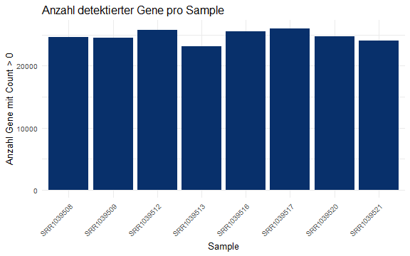

Anzahl der Gene mit Count > 0 pro Sample.

```r
ggplot(
  sample_qc,
  aes(
    x = sample,
    y = detected_genes
  )
) +
  geom_col(
    fill = "#08306B"
  ) +
  labs(
    title = "Anzahl detektierter Gene pro Sample",
    x = "Sample",
    y = "Anzahl Gene mit Count > 0"
  ) +
  theme_minimal(base_size = 13) +
  theme(
    axis.text.x = element_text(
      angle = 45,
      hjust = 1
    )
  )
```

### 3.1.3 Mean-Varianz- und Mean-SD-Analyse

Die Mean-Varianz-Analyse zeigt, dass die Varianz mit zunehmender mittlerer Expression deutlich ansteigt. Damit liegt in den Rohdaten eine ausgeprägte Abhängigkeit der Streuung vom Expressionsniveau vor. Der Mean-SD-Plot bestätigt dieses Muster. Für nachfolgende explorative Analysen ist daher eine Varianzstabilisierung sinnvoll.

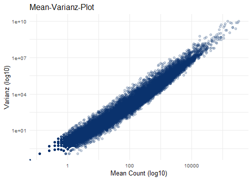

Mean-Varianz-Beziehung der Rohcounts.

```r
# 6. Mean-Varianz-Analyse

gene_mean <- rowMeans(count_matrix)

gene_variance <- apply(
  count_matrix,
  1,
  var
)

mean_variance <- data.frame(
  gene = rownames(count_matrix),
  mean = gene_mean,
  variance = gene_variance
)

ggplot(
  mean_variance,
  aes(
    x = mean,
    y = variance
  )
) +
  geom_point(
    alpha = 0.2,
    color = "#08306B"
  ) +
  scale_x_log10() +
  scale_y_log10() +
  labs(
    title = "Mean-Varianz-Plot",
    x = "Mean Count (log10)",
    y = "Varianz (log10)"
  ) +
  theme_minimal(base_size = 13)
```

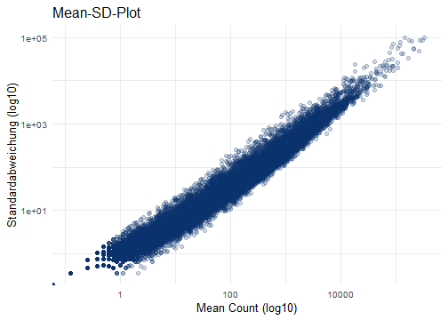

Mean-SD-Beziehung der Rohcounts.

```r
# 7. Mean-SD-Plot

gene_sd <- apply(
  count_matrix,
  1,
  sd
)

mean_sd_raw <- data.frame(
  gene = rownames(count_matrix),
  mean = gene_mean,
  sd = gene_sd
)

ggplot(
  mean_sd_raw,
  aes(
    x = mean,
    y = sd
  )
) +
  geom_point(
    alpha = 0.2,
    color = "#08306B"
  ) +
  scale_x_log10() +
  scale_y_log10() +
  labs(
    title = "Mean-SD-Plot",
    x = "Mean Count (log10)",
    y = "Standardabweichung (log10)"
  ) +
  theme_minimal(base_size = 13)
```

Eine zusätzliche log2-Transformation wird im QA ausschließlich diagnostisch eingesetzt. Sie reduziert die Abhängigkeit der Streuung vom Mittelwert sichtbar und liefert damit einen Hinweis darauf, dass eine Transformation der Daten für weitere explorative Analysen hilfreich ist.

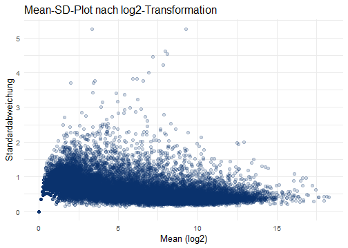

Mean-SD-Beziehung nach diagnostischer log2-Transformation.

```r
# 8. Log2 Transformation und Mean-SD-Plot mit log2 Daten

log_counts <- log2(
  count_matrix + 1
)

# mean-sd mit log2

log_mean <- rowMeans(log_counts)

log_sd <- apply(
  log_counts,
  1,
  sd
)

mean_sd_log <- data.frame(
  gene = rownames(log_counts),
  mean = log_mean,
  sd = log_sd
)

ggplot(
  mean_sd_log,
  aes(
    x = mean,
    y = sd
  )
) +
  geom_point(
    alpha = 0.2,
    color = "#08306B"
  ) +
  labs(
    title = "Mean-SD-Plot nach log2-Transformation",
    x = "Mean (log2)",
    y = "Standardabweichung"
  ) +
  theme_minimal(base_size = 13)
```

## 3.2 Quality Control

Auf Grundlage des QA werden im Quality Control (QC) Gene mit sehr geringer Expression gefiltert. Hierzu wird mit `edgeR` ein `DGEList`-Objekt erstellt und `filterByExpr()` angewendet. Die nach der Filterung verbliebenen Gene werden anschließend wieder in die Long-Tabelle zurückgeführt und als Grundlage für die weiteren Analyseschritte verwendet.

```r
# 1. AUSGABEVERZEICHNIS

output_dir <- "data"

if (!dir.exists(output_dir)) {
  dir.create(output_dir, recursive = TRUE)
}


# 2. SPALTEN CHECKEN

required_cols <- c(
  "gene_id",
  "sample",
  "counts"
)

missing_cols <- setdiff(
  required_cols,
  colnames(data)
)

if (length(missing_cols) > 0) {
  stop(
    "Fehlende Pflichtspalten: ",
    paste(missing_cols, collapse = ", ")
  )
}


# 3. DATENTYPEN KONTROLLIEREN

data <- data %>%
  mutate(
    gene_id = as.character(gene_id),
    sample = as.character(sample),
    counts = as.numeric(counts)
  )

if (any(is.na(data$counts)) || any(data$counts < 0)) {
  stop("'counts' enthält NA oder negative Werte.")
}

data <- data %>%
  mutate(
    counts = as.integer(round(counts))
  )


# 4. COUNT-MATRIX AUS DER CSV ERSTELLEN

count_data <- data %>%
  select(
    gene_id,
    sample,
    counts
  ) %>%
  pivot_wider(
    names_from = sample,
    values_from = counts
  )

count_data <- as.data.frame(count_data)

rownames(count_data) <- count_data$gene_id

count_data$gene_id <- NULL

count_matrix <- as.matrix(count_data)


# Kontrolle

cat("\nDimension der Count-Matrix: ")
print(dim(count_matrix))


# 5. edgeR DGEList ERSTELLEN

dge <- DGEList(
  counts = count_matrix
)


# 6. LOW-COUNT-FILTERUNG MIT filterByExpr()

keep <- filterByExpr(dge)

cat("\nGene vor Filterung: ", nrow(dge), "\n")
cat("Gene nach Filterung: ", sum(keep), "\n")
cat("Entfernte Gene: ", sum(!keep), "\n")

if (sum(keep) == 0) {
  stop("Kein Gen erfüllt die filterByExpr()-Kriterien.")
}

filtered_count_matrix <- count_matrix[
  keep,
  ,
  drop = FALSE
]


# 7. GEFILTERTE GENE WIEDER IN DIE LONG-TABELLE ZURÜCKFÜHREN

filtered_gene_ids <- rownames(
  filtered_count_matrix
)

data_filtered <- data %>%
  filter(
    gene_id %in% filtered_gene_ids
  )


# 8. GEFILTERTE DATEN ALS CSV SPEICHERN

output_file <- file.path(
  output_dir,
  "Daten_roh_long_filtered.csv"
)

write_csv(
  data_filtered,
  output_file,
  na = ""
)


# 9. AUSGABE FÜR ÜBERSICHT

cat("\nLow-Count-Filterung abgeschlossen.\n")

cat(
  "Gene vor Filterung: ",
  nrow(count_matrix),
  "\n"
)

cat(
  "Gene nach Filterung: ",
  nrow(filtered_count_matrix),
  "\n"
)

cat(
  "Entfernte Gene: ",
  sum(!keep),
  "\n"
)

cat(
  "Zeilen vor Filterung: ",
  nrow(data),
  "\n"
)

cat(
  "Zeilen nach Filterung: ",
  nrow(data_filtered),
  "\n"
)

cat(
  "Ausgabedatei: ",
  output_file,
  "\n"
)
```

Ergebnis der Low-Count-Filterung.

| Kennzahl | Anzahl |
| --- | --- |
| Gene vor Filterung | 63677 |
| Gene nach Filterung | 14224 |
| Entfernte Gene | 49453 |

# 4 Preprocessing und Normalisierung

Nach der Low-Count-Filterung werden die Daten für die statistischen und explorativen Analysen weiterverarbeitet. Zunächst wird erneut geprüft, ob die erforderlichen Spalten vorhanden sind und ob die Counts gültige nichtnegative Integer-Werte darstellen. Anschließend wird eine Count-Matrix erstellt und die Metadaten werden in exakt dieselbe Reihenfolge wie die Samples der Matrix gebracht.

Für die Normalisierung wird ein DESeq2-Objekt mit dem Design `~ cell + dex` erzeugt. Dadurch werden sowohl die vier Zelllinien als auch der Behandlungsstatus im Datensatz beschrieben. Mittels `estimateSizeFactors()` werden Unterschiede in Sequenziertiefe und Library Size berücksichtigt und normalisierte Counts berechnet.

Anschließend wird eine Variance Stabilizing Transformation (VST) durchgeführt. Ziel ist es, die Abhängigkeit der Varianz vom mittleren Expressionsniveau zu reduzieren und die Daten damit für explorative Verfahren wie PCA, Clustering und Heatmaps geeigneter zu machen.

```r
# 1. Einlesen der gefilterten Rohdaten

fil_Daten <- data_filtered

# 2. Prüfung der überreichten Daten_roh_long_filtered.csv

##Prüfung ob alle nötigen Spalten noch vorliegen

required_cols <- c(
  "gene_id",
  "sample",
  "counts",
  "cell",
  "dex"
)

missing_cols <- setdiff(required_cols, colnames(fil_Daten))

if (length(missing_cols) > 0) {
  stop(
    "Fehlende nötige Spalten: ",
    paste(missing_cols, collapse = ", ")
  )
}

## Prüfung ob NA- oder negative Werte vorliegen und ob alle Werte Integer sind

if (any(is.na(fil_Daten$counts))) {
  stop("'counts' -> NA-Werte.")
}

if (any(fil_Daten$counts < 0)) {
  stop("'counts' -> negative Werte.")
}

if (any(fil_Daten$counts != round(fil_Daten$counts))) {
  stop("'counts' -> keine reinen Integer.")
}

## Prüfung der eindeutigen Definition aller Samples

Probeninformationen <- fil_Daten %>%
  distinct(sample, cell, dex)

if (nrow(Probeninformationen) != n_distinct(fil_Daten$sample)) {
  stop(
    "Min. ein Sample besitzt mehrere unterschiedliche ",
    "cell- oder dex-Zuordnungen."
  )
}

# 3. Extrahierung einer Count-Matrix aus fil_Daten

Daten_matrix <- fil_Daten %>%
  group_by(gene_id, sample) %>%
  summarise(
    counts = sum(counts),
    .groups = "drop"
  ) %>%
  pivot_wider(
    names_from = sample,
    values_from = counts,
    values_fill = 0
  ) %>%
  as.data.frame()

rownames(Daten_matrix) <- Daten_matrix$gene_id
Daten_matrix$gene_id <- NULL

Daten_matrix <- as.matrix(Daten_matrix)

storage.mode(Daten_matrix) <- "integer"

## Überprüfung der Matrix

dim(Daten_matrix)

head(Daten_matrix[, 1:4])

colnames(Daten_matrix)

# 4. Probeninformationen (Metadaten) zuordnen

Probeninformationen <- fil_Daten %>%
  distinct(sample, cell, dex) %>%
  as.data.frame()

rownames(Probeninformationen) <- Probeninformationen$sample

Probeninformationen <- Probeninformationen[
  colnames(Daten_matrix),
  ,
  drop = FALSE
]

## Prüfung der korrekten Daten-Metadatenzuordnung

stopifnot(
  identical(
    rownames(Probeninformationen),
    colnames(Daten_matrix)
  )
)

# 5. Beginn des Preprocessing/Normalisierens - Erstellen eines DESeq2-Objekts

Probeninformationen$cell <- factor(Probeninformationen$cell)
Probeninformationen$dex <- factor(Probeninformationen$dex)

dds <- DESeqDataSetFromMatrix(
  countData = Daten_matrix,
  colData = Probeninformationen,
  design = ~ cell + dex
)

# 6. Size-Factor-Normalisierung

dds <- estimateSizeFactors(dds)

sizeFactors(dds)

# 7. Normalisierung der Messdaten

normalisierte_counts <- counts(
  dds,
  normalized = TRUE
)

# 8. Kontrolle der normalisierten Counts

dim(normalisierte_counts)

head(normalisierte_counts[, 1:4])

data.frame(
  sample = colnames(Daten_matrix),
  size_factor = sizeFactors(dds)
)

# 9. Variance Stabilizing Transformation (VST)

vst_daten <- vst(
  dds,
  blind = TRUE
)

vst_matrix <- assay(vst_daten)

# 10. QA der Size Factors

size_factor_info <- data.frame(
  sample = colnames(Daten_matrix),
  cell = Probeninformationen$cell,
  dex = Probeninformationen$dex,
  size_factor = sizeFactors(dds)
)

print(size_factor_info)

# 11. QA der Library Size

library_größe <- colSums(Daten_matrix)

library_info <- data.frame(
  sample = names(library_größe),
  library_größe = as.numeric(library_größe),
  size_factor = sizeFactors(dds)
)

print(library_info)

# 12. QA der VST-Matrix

dim(vst_matrix)

head(vst_matrix[, 1:4])

# 13. QA des Mean-Variance-Plots
```

## 4.1 Kontrolle der VST

Nach der VST werden Mittelwert und Varianz jedes Gens erneut betrachtet. Gegenüber den Rohcounts ist die Abhängigkeit der Varianz vom mittleren Expressionsniveau deutlich abgeschwächt.

[figure not shown]

Mittelwert-Varianz-Beziehung nach VST.

```r
# 14. Ergebnisse speichern

output_dir_data <- "data"
output_dir_images <- "images"

vst_ergebnisse <- as.data.frame(vst_matrix) %>%
  rownames_to_column("gene_id")

normalisierte_ergebnisse <- as.data.frame(normalisierte_counts) %>%
  rownames_to_column("gene_id")

normalisierungs_info <- Probeninformationen %>%
  mutate(
    size_factor = sizeFactors(dds)
  )

png(
  filename = file.path(
    output_dir_images,
    "VST_Mittelwert-Varianz-Beziehung.png"
  ),
  width = 1600,
  height = 1200,
  res = 200
)

plot(
  vst_mean,
  vst_variance,
  log = "xy",
  pch = 16,
  cex = 0.4,
  xlab = "Mittlere VST-Expression",
  ylab = "Varianz",
  main = "Mittelwert-Varianz-Beziehung nach erfolgter VST"
)

dev.off()

write_csv(
  normalisierte_ergebnisse,
  file.path(
    output_dir_data,
    paste0("DESeq2_normalisierte_counts.csv")
  ),
  na = ""
)

write_csv(
  vst_ergebnisse,
  file.path(
    output_dir_data,
    paste0("VST_transformierte_Daten.csv")
  ),
  na = ""
)

write_csv(
  normalisierungs_info,
  file.path(
    output_dir_data,
    paste0("Probeninformationen_Normalisierung.csv")
  ),
  na = ""
)
```

# 5 Differential-Expression-Analyse

Mithilfe der Differential-Expression-Analyse wird untersucht, wie sich die Genexpression zwischen unbehandelten und mit Dexamethason behandelten Proben verändert. Für jedes Gen werden unter anderem ein log2-Fold-Change als Maß für Stärke und Richtung der Expressionsänderung sowie statistische Signifikanzmaße berechnet.

Für die Analyse werden die gefilterten Rohcounts verwendet, da DESeq2 eine eigene Normalisierung durchführt. Die Daten werden dafür aus dem Long-Format in eine Count-Matrix überführt. `dex` und `cell` werden als Faktoren definiert und `untrt` wird als Referenzlevel für den Behandlungsfaktor festgelegt. Dadurch beschreibt ein positiver log2-Fold-Change eine höhere Expression unter Dexamethason im Vergleich zu unbehandelten Zellen.

Das DESeq2-Modell verwendet das Design `~ cell + dex`. Unterschiede zwischen den Zelllinien werden damit im statistischen Modell berücksichtigt, während der Dexamethason-Effekt über alle vier Zelllinien hinweg geschätzt wird. Gene mit einem adjustierten p-Wert (`padj`) kleiner als 0,05 werden in dieser Analyse als statistisch signifikant betrachtet.

Da log2-Fold-Changes insbesondere bei geringer Information oder hoher Streuung unsicher und überschätzt sein können, werden die Effektgrößen mit `lfcShrink(..., type = "apeglm")` stabilisiert. Anschließend werden Genannotation und statistische Ergebnisse zu einer gemeinsamen Tabelle zusammengeführt.

```r
# 1. Daten aus csv laden
Daten_roh_long_filtered <- data_filtered

Tab_Probeninformationen <- as.data.frame(
  Tab_Probeninformationen
)

# 2. Daten_roh_long_filtered für DESeq2 vorbereiten. Umwandlung in eine wide-format count Matrix. Die Spaltennamen
# der count matrix müssen mit den Zeilennamen der Metadaten übereinstimmen
count_mat <- Daten_roh_long_filtered %>%
  select (gene_id, sample, counts) %>%
  pivot_wider (
    names_from = sample,
    values_from = counts
  ) %>%
  column_to_rownames("gene_id") %>%
  as.matrix()


# 3. cell und dex als Faktoren definieren. Somit kann für die spätere Auswertung mit DESeq2 in Kategorien
# wie treated und untreated und in die vier unterschiedlichen Zelllinien/Spender eingeteilt werden.
Tab_Probeninformationen$cell <-
  factor(Tab_Probeninformationen$cell)

Tab_Probeninformationen$dex <-
  factor(Tab_Probeninformationen$dex)

rownames(Tab_Probeninformationen) <- Tab_Probeninformationen$Run

# Faktoren können überprüft werden
levels(Tab_Probeninformationen$cell)


# 4. Untreated als Referenzgruppe festlegen. So kann später intuitiver bestimmt werden, wie sich die Behandlung
# im Gegensatz zu keiner Behandlung auf die Genexpression auswirkt.
Tab_Probeninformationen$dex <- relevel(
  Tab_Probeninformationen$dex,
  ref = "untrt"
)

#Überprüfen ob untrt wirklich als Referenzlevel festgelegt wurde. Reihenfolge muss "untrt" "trt" sein
levels(Tab_Probeninformationen$dex)

# 5. Für DESeq2 müssen Reihenfolge der Count Matrix mit den Metadaten identisch sein. Dies wird überprüft. Falls es nicht stimmt
# bricht das Skript ab
stopifnot(
  identical(
    colnames(count_mat),
    rownames(Tab_Probeninformationen)
  )
)

# 6. DESeq2 durchführen
dds <- DESeqDataSetFromMatrix(
  countData = count_mat,
  colData = Tab_Probeninformationen,
  design = ~ cell+dex

)

dds <- DESeq(dds)
#Überprüfen, ob resultsNames(dds) dex_trt_vs_untrt entspricht, da dieser Koeffizient später noch verwendet wird
stopifnot(
  "dex_trt_vs_untrt" %in% resultsNames(dds)
)

# 7. Differentiale Genexpression zwischen behandelten (trt) und unbehandelten
# Proben (untrt) testen. Alpha = 0.05 beschreibt, dass Gene mit einem adjustierten p-value <0,05 signifikant sind.
res <- results(
  dds,
  contrast = c("dex","trt","untrt"),
  alpha = 0.05
)
summary(res)


# 8. Log2-FC shrinken, um unsichere oder möglicherweise überschätzte Effekte, besonders bei Genen mit wenigen Counts oder hoher Streuung, zu stabilisieren.
res_shrunk <- lfcShrink(
  dds,
  coef = "dex_trt_vs_untrt",
  type = "apeglm"
)

# 9. Ergebnisse sollen übersichtlicher gestaltet werden, weshalb Geninformationen dazugeholt werden. Zunächst wird eine Annotationstabelle erstellt.
annotation <- Daten_roh_long_filtered %>%
  select(
    gene_id,
    gene_name,
    symbol,
    gene_biotype
  ) %>%
  distinct()

# 10. DESeq2 Ergebnisse werden in Data Frame umgewandelt.
res_df <- as.data.frame(res_shrunk) %>%
  rownames_to_column("gene_id")

# 11. Annotation anhängen
res_df <- res_df %>%
  left_join(
    annotation,
    by = "gene_id"
  )

# 12. Nach Signifikanz sortieren. Kleinsten padj kommen nach oben.
res_df <- res_df %>%
  arrange(padj)

# 13. Eigene Tabelle für signifikante Gene (padj < 0.05) erstellen.
sig <- res_df %>%
  filter(
    !is.na(padj),
    padj < 0.05
  )

# 14. Übersichtlichere Tabelle mit signifikanten Werten und wichtigen Informationen.
sig <- sig %>%
  select(
    gene_id,
    gene_name,
    symbol,
    gene_biotype,
    baseMean,
    log2FoldChange,
    lfcSE,
    pvalue,
    padj
  )

# 15. Betrachtung nur hochregulierter und dann nur herunterregulierter Gene nach der Behandlung.
sig_up <- sig %>%
  filter(log2FoldChange > 0)

sig_down <- sig %>%
  filter(log2FoldChange < 0)

# 16. Sortieren nach dem stärksten Effekt. Welche Gene besitzen einen hohen LFC. Welche wurden besonders stark hochreguliert?
sig_up %>%
  arrange(desc(log2FoldChange)) %>%
  select(
    symbol,
    gene_name,
    baseMean,
    log2FoldChange,
    padj
  ) %>%
  head(20)

# 17. Welche Gene wurden am stärksten runterreguliert?
sig_down %>%
  arrange(log2FoldChange) %>%
  select(
    symbol,
    gene_name,
    baseMean,
    log2FoldChange,
    padj
  ) %>%
  head(20)

# 18.Ergebnistabelle als csv speichern
# Komplette annotierte Tabelle
write_csv(
  res_df,
  "data/DESeq2_Ergebnisse_alle_Gene.csv"
)
# Nur signifikante Gene
write_csv(
  sig,
  "data/DESeq2_signifikante_Gene.csv"
)
```

## 5.1 Besonders stark regulierte Gene

Im resultierenden Datensatz zeigt `SPARCL1` (`ENSG00000152583`) mit einem log2-Fold-Change von ungefähr 4,55 die stärkste Hochregulation. `VCAM1` (`ENSG00000162692`) weist mit einem log2-Fold-Change von ungefähr -3,68 die stärkste Herunterregulation auf.

Stärkste signifikant hochregulierte Gene.

| symbol | gene_name | baseMean | log2FoldChange | padj |
| --- | --- | --- | --- | --- |
| SPARCL1 | SPARCL1 | 997.958 | 4.549 | 7.40e-132 |
| KLF15 | KLF15 | 561.418 | 4.425 | 6.77e-78 |
| FKBP5 | FKBP5 | 2566.227 | 3.960 | 6.74e-26 |
| ADRA1B | ADRA1B | 201.779 | 3.922 | 5.58e-15 |
| SAMHD1 | SAMHD1 | 12714.667 | 3.747 | 6.20e-125 |
| GPX3 | GPX3 | 12298.969 | 3.712 | 6.30e-107 |
| ITGA10 | ITGA10 | 266.099 | 3.696 | 5.74e-16 |
| INHBB | INHBB | 419.145 | 3.414 | 1.27e-58 |
| MAOA | MAOA | 2343.870 | 3.330 | 2.12e-119 |
| CACNB2 | CACNB2 | 495.667 | 3.270 | 7.40e-132 |

Stärkste signifikant herunterregulierte Gene.

| symbol | gene_name | baseMean | log2FoldChange | padj |
| --- | --- | --- | --- | --- |
| VCAM1 | VCAM1 | 511.595 | -3.684 | 9.27e-82 |
| FER1L6 | FER1L6 | 244.993 | -3.030 | 1.60e-32 |
| WNT2 | WNT2 | 335.946 | -3.030 | 1.29e-55 |
| AQP3 | AQP3 | 139.587 | -2.869 | 2.60e-21 |
| SLC7A14 | SLC7A14 | 246.188 | -2.861 | 9.64e-39 |
| TSLP | TSLP | 153.364 | -2.756 | 5.61e-32 |
| PRSS35 | PRSS35 | 315.870 | -2.750 | 4.46e-70 |
| AIF1L | AIF1L | 93.978 | -2.634 | 5.87e-25 |
| LIF | LIF | 154.100 | -2.560 | 1.11e-20 |
| ADCY1 | ADCY1 | 355.736 | -2.551 | 1.08e-23 |

## 5.2 MA-Plot

Der MA-Plot stellt für jedes Gen den mittleren normalisierten Count (`baseMean`) gegen den geshrinkten log2-Fold-Change dar. Werte oberhalb von null entsprechen einer höheren Expression unter Dexamethason, Werte unterhalb von null einer niedrigeren Expression.

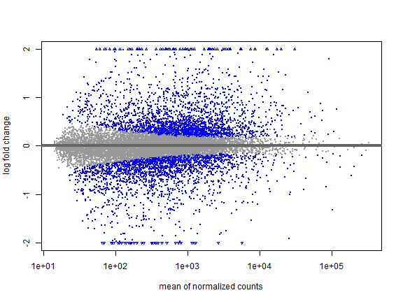

MA-Plot der geshrinkten log2-Fold-Changes.

# 6 Dimensionsreduktion und Visualisierung

Die VST-transformierte Expressionsmatrix wird für die Dimensionsreduktion so transponiert, dass die Samples in den Zeilen und die Gene in den Spalten liegen. Anschließend werden die Genfeatures z-standardisiert. Auf dieser Matrix werden PCA, t-SNE und UMAP durchgeführt. Die drei Verfahren dienen hier der explorativen Darstellung der acht Proben und nicht der Reproduktion einer Analyse aus der ursprünglichen Publikation.

Die PCA stellt die größten linearen Varianzrichtungen dar. t-SNE und UMAP sind nichtlineare Verfahren, die insbesondere lokale Nachbarschaften visualisieren. Aufgrund der sehr kleinen Stichprobengröße von acht Samples werden t-SNE und UMAP ausschließlich explorativ interpretiert; insbesondere globale Abstände und Achsenwerte sollten nicht überinterpretiert werden.

```r
# 1. Zeilen: Samples, Spalten: Gene
mat_t <- t(vst_matrix)

# 2. Features skalieren
mat_scaled <- scale(mat_t)

# 3. Dimensionsreduktion

plot_info <- Probeninformationen %>%
  as.data.frame() %>%
  select(
    sample,
    cell,
    dex
  )

## 3.1 PCA
pca_res <- prcomp(mat_scaled, center = FALSE, scale. = FALSE)
pca_variance <- (pca_res$sdev^2 / sum(pca_res$sdev^2)) * 100
pca_df  <- as_tibble(pca_res$x[,1:2], rownames = "sample") %>%
  set_names("sample","PC1","PC2")
pca_df <- pca_df %>%
  left_join(
    plot_info,
    by = "sample"
  )

## 3.2 t-SNE (Perplexity automatisch anpassen)
n_samp   <- nrow(mat_scaled)
max_p     <- floor((n_samp - 1) / 3)
perplex  <- if (max_p >= 5) 30 else max_p
message("Verwende t-SNE perplexity = ", perplex)
set.seed(42)
tsne_res <- Rtsne(mat_scaled, dims = 2, perplexity = perplex, verbose = TRUE)
tsne_df  <- as_tibble(tsne_res$Y, .name_repair = "minimal") %>%
  set_names("TSNE1","TSNE2") %>%
  mutate(sample = rownames(mat_scaled))
tsne_df <- tsne_df %>%
  left_join(
    plot_info,
    by = "sample"
  )

## 3.3 UMAP (n_neighbors automatisch anpassen)
n_nbrs   <- min(15, n_samp - 1)
message("Verwende UMAP n_neighbors = ", n_nbrs)
set.seed(42)
umap_res <- umap(mat_scaled, n_neighbors = n_nbrs, min_dist = 0.1)
umap_df  <- as_tibble(umap_res, .name_repair = "minimal") %>%
  set_names("UMAP1","UMAP2") %>%
  mutate(sample = rownames(mat_scaled))
umap_df <- umap_df %>%
  left_join(
    plot_info,
    by = "sample"
  )
```

## 6.1 PCA

Die Samples werden in den ersten beiden Hauptkomponenten dargestellt. Die Farbe kennzeichnet den Behandlungsstatus und die Symbolform die jeweilige Zelllinie. Dadurch lassen sich Behandlungs- und Zelllinienstruktur direkt gemeinsam beurteilen. In der vorliegenden Analyse zeigt sich eine deutliche Dexamethason-assoziierte Trennung entlang der ersten Hauptkomponente, während auf der zweiten Hauptkomponente weiterhin zelllinienspezifische Unterschiede sichtbar sind.

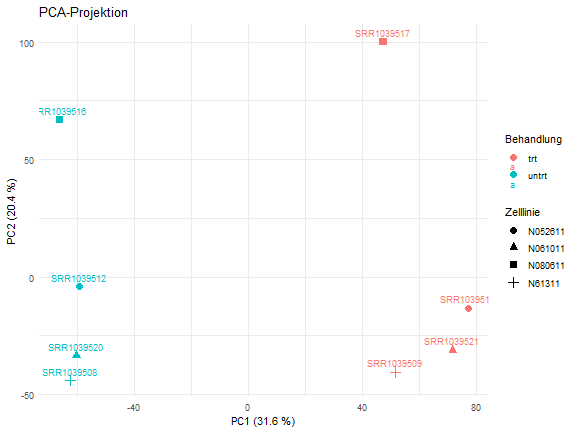

PCA der z-standardisierten VST-Expressionsprofile. Farbe: Behandlung; Symbol: Zelllinie.

## 6.2 t-SNE

t-SNE betont lokale Nachbarschaften und bildet die hochdimensionalen Expressionsprofile in zwei Dimensionen ab. Bei nur acht Proben ist die Darstellung stark explorativ; insbesondere große Distanzen zwischen Punkten oder Clustern werden nicht als quantitatives Maß biologischer Unterschiede interpretiert.

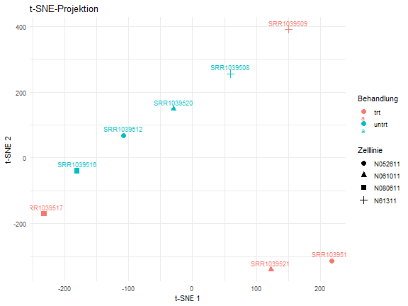

t-SNE-Darstellung der acht Airway-Proben. Farbe: Behandlung; Symbol: Zelllinie.

## 6.3 UMAP

Auch UMAP wird als ergänzende explorative Projektion verwendet. Die Darstellung kann lokale Gruppierungen sichtbar machen, die geometrischen Abstände im zweidimensionalen UMAP-Raum werden jedoch nicht als direkte quantitative Distanzen der ursprünglichen Genexpressionsprofile interpretiert.

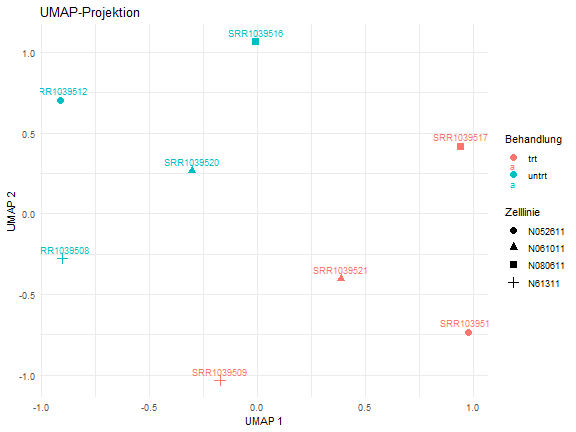

UMAP-Darstellung der acht Airway-Proben. Farbe: Behandlung; Symbol: Zelllinie.

# 7 Clustering

## 7.1 Fragestellung und Hypothese

Mittels unüberwachtem Clustering wird untersucht, ob sich die acht Airway-Proben allein anhand ihrer Genexpressionsprofile in biologisch sinnvolle Gruppen einteilen lassen. Im Mittelpunkt steht die Frage, ob die Clusterstruktur eher dem Dexamethason-Behandlungsstatus oder den vier untersuchten Zelllinien entspricht.

Es wird die Hypothese aufgestellt, dass die Behandlung mit Dexamethason zu systematischen Veränderungen des Genexpressionsprofils führt und sich behandelte und unbehandelte Proben daher auch ohne Verwendung der bekannten Gruppeninformation voneinander trennen lassen.

Für das Clustering werden die nach der Qualitätskontrolle verbliebenen und VST-transformierten Expressionsdaten verwendet. Eine zusätzliche z-Standardisierung wird bewusst nicht durchgeführt, sodass Gene mit größerer biologischer Variation auch stärker zu den Distanzen beitragen können.

## 7.2 Hierarchisches Clustering

Zunächst wird die euklidische Distanz zwischen den acht Proben auf Grundlage der VST-transformierten Expressionswerte berechnet. Auf dieser Distanzmatrix wird ein hierarchisches Clustering mit Complete Linkage durchgeführt. Mit `cutree(..., k = 2)` wird das Dendrogramm anschließend in zwei Hauptcluster unterteilt und mit dem bekannten Treatment-Label verglichen.

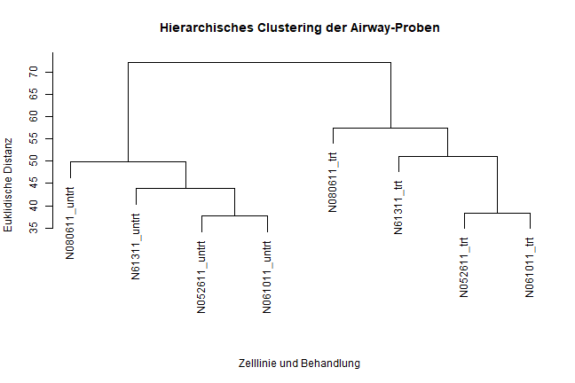

Hierarchisches Clustering der Airway-Proben mit Complete Linkage.

Clusterzuordnung im Vergleich zum Behandlungsstatus.

| trt | untrt |
| --- | --- |
| 0 | 4 |
| 4 | 0 |

```r
# 1. Expressionsmatrix und Metadaten vorbereiten

metadata <- Probeninformationen

metadata <- metadata %>%
  slice(match(colnames(vst_matrix), sample))

stopifnot(
  identical(metadata$sample, colnames(vst_matrix))
)

metadata <- metadata %>%
  mutate(
    cluster_label = paste(cell, dex, sep = "_")
  )

sample_labels <- metadata$cluster_label
names(sample_labels) <- metadata$sample

# Keine zusätzliche z-Standardisierung:
# Die Expressionswerte liegen bereits VST-transformiert auf einer gemeinsamen
# Skala vor. Eine genweise Standardisierung würde jedem Gen unabhängig von
# seiner biologischen Variabilität ein vergleichbares Gewicht geben und damit
# eine andere Fragestellung untersuchen.


# 2. Euklidische Distanz und hierarchisches Clustering

sample_dist <- dist(
  t(vst_matrix),
  method = "euclidean"
)

hc_complete <- hclust(
  sample_dist,
  method = "complete"
)

hc_complete_labels <- hc_complete
hc_complete_labels$labels <- sample_labels[
  hc_complete_labels$labels
]

plot(
  hc_complete_labels,
  main = "Hierarchisches Clustering der Airway-Proben",
  xlab = "Zelllinie und Behandlung",
  ylab = "Euklidische Distanz",
  sub = ""
)
```

Complete Linkage erzeugt zwei Hauptcluster, die vollständig den beiden Behandlungsgruppen entsprechen: Alle vier unbehandelten Proben liegen in einem Cluster und alle vier Dexamethason-behandelten Proben im zweiten Cluster.

## 7.3 Vergleich der Linkage-Verfahren

Zusätzlich werden Single, Average, Complete und Ward.D2 Linkage miteinander verglichen. Die Funktion `is_treatment_separation()` prüft, ob die jeweils zwei resultierenden Cluster vollständig den beiden Treatment-Gruppen entsprechen.

```r
# 3. Robustheitsprüfung verschiedener Linkage-Verfahren

hc_single <- hclust(
  sample_dist,
  method = "single"
)

hc_average <- hclust(
  sample_dist,
  method = "average"
)

hc_ward <- hclust(
  sample_dist,
  method = "ward.D2"
)

# Prüft, ob k = 2 exakt nach Treatment trennt
is_treatment_separation <- function(cluster_assignment, metadata) {

  dex_ordered <- metadata$dex[
    match(names(cluster_assignment), metadata$sample)
  ]

  trt_cluster <- unique(
    cluster_assignment[dex_ordered == "trt"]
  )

  untrt_cluster <- unique(
    cluster_assignment[dex_ordered == "untrt"]
  )

  length(trt_cluster) == 1 &&
    length(untrt_cluster) == 1 &&
    trt_cluster != untrt_cluster
}

linkage_results <- tibble(
  linkage = c(
    "Single",
    "Average",
    "Complete",
    "Ward.D2"
  ),
  treatment_separation = c(
    is_treatment_separation(
      cutree(hc_single, k = 2),
      metadata
    ),
    is_treatment_separation(
      cutree(hc_average, k = 2),
      metadata
    ),
    is_treatment_separation(
      cutree(hc_complete, k = 2),
      metadata
    ),
    is_treatment_separation(
      cutree(hc_ward, k = 2),
      metadata
    )
  )
)

print(linkage_results)
```

Robustheit der Treatment-Trennung gegenüber dem Linkage-Verfahren.

| Linkage-Verfahren | Vollständige Treatment-Trennung |
| --- | --- |
| Single | nein |
| Average | ja |
| Complete | ja |
| Ward.D2 | ja |

Single Linkage reproduziert die Treatment-Trennung nicht. Average, Complete und Ward.D2 führen dagegen zu einer vollständigen Trennung nach Behandlungsstatus.

## 7.4 Einfluss der Feature-Auswahl

Um zu prüfen, ob die beobachtete Clusterstruktur von einer kleinen Zahl hochvariabler Gene abhängt, werden zunächst die 500 variabelsten Gene ausgewählt. Die Auswahl erfolgt ausschließlich anhand der Genvarianz und damit unabhängig vom bekannten Treatment-Label.

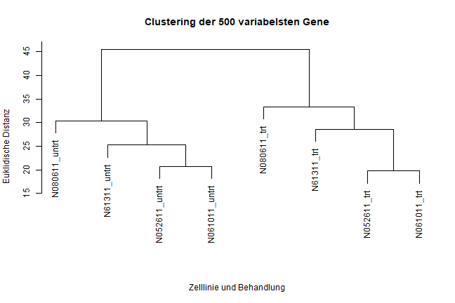

Hierarchisches Clustering auf Basis der 500 variabelsten Gene.

```r
# 4. Feature-Auswahl anhand der Genvarianz

gene_variance <- apply(
  vst_matrix,
  1,
  var
)

top500_genes <- names(
  sort(
    gene_variance,
    decreasing = TRUE
  )
)[1:500]

vst_top500 <- vst_matrix[
  top500_genes,
  ,
  drop = FALSE
]

sample_dist_top500 <- dist(
  t(vst_top500),
  method = "euclidean"
)

hc_top500 <- hclust(
  sample_dist_top500,
  method = "complete"
)

hc_top500_labels <- hc_top500
hc_top500_labels$labels <- sample_labels[
  hc_top500_labels$labels
]

plot(
  hc_top500_labels,
  main = "Clustering der 500 variabelsten Gene",
  xlab = "Zelllinie und Behandlung",
  ylab = "Euklidische Distanz",
  sub = ""
)
```

Auch bei Beschränkung auf die 500 variabelsten Gene werden behandelte und unbehandelte Proben vollständig voneinander getrennt.

Zusätzlich wird die Feature-Anzahl systematisch variiert.

```r
# 5. Sensitivitätsanalyse der Feature-Anzahl

n_genes <- c(
  100,
  250,
  500,
  1000,
  5000
)

feature_results <- lapply(
  n_genes,
  function(n) {

    selected_genes <- names(
      sort(
        gene_variance,
        decreasing = TRUE
      )
    )[1:n]

    matrix_subset <- vst_matrix[
      selected_genes,
      ,
      drop = FALSE
    ]

    dist_subset <- dist(
      t(matrix_subset),
      method = "euclidean"
    )

    hc_subset <- hclust(
      dist_subset,
      method = "complete"
    )

    clusters <- cutree(
      hc_subset,
      k = 2
    )

    tibble(
      genes = n,
      treatment_separation = is_treatment_separation(
        clusters,
        metadata
      )
    )
  }
) %>%
  bind_rows()

print(feature_results)
```

Sensitivitätsanalyse der Feature-Anzahl.

| Anzahl variabler Gene | Vollständige Treatment-Trennung |
| --- | --- |
| 100 | nein |
| 250 | ja |
| 500 | ja |
| 1000 | ja |
| 5000 | ja |

Bei nur 100 hochvariablen Genen geht die eindeutige Treatment-Trennung verloren. Ab 250 hochvariablen Genen bleibt sie erhalten.

## 7.5 Sample-Distanzen

Die vollständige Distanzmatrix wird ergänzend als Heatmap dargestellt. Dadurch können die paarweisen Distanzen zwischen allen acht Proben zusätzlich zur hierarchischen Baumstruktur beurteilt werden.

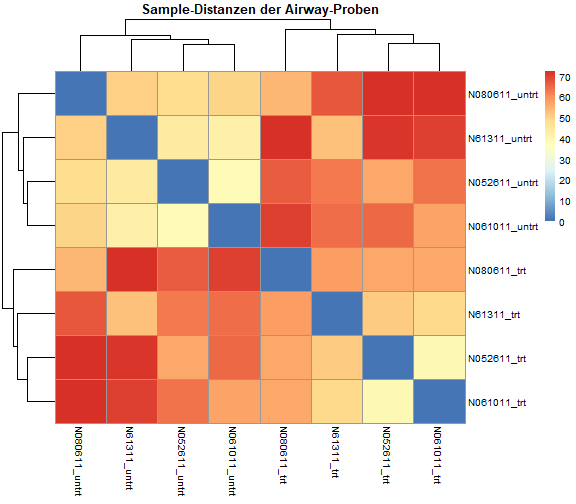

Heatmap der euklidischen Sample-Distanzen.

```r
# 6. Sample-Distance-Heatmap

sample_dist_matrix <- as.matrix(
  sample_dist
)

rownames(sample_dist_matrix) <- sample_labels[
  rownames(sample_dist_matrix)
]

colnames(sample_dist_matrix) <- sample_labels[
  colnames(sample_dist_matrix)
]

pheatmap(
  sample_dist_matrix,
  cluster_rows = hc_complete_labels,
  cluster_cols = hc_complete_labels,
  main = "Sample-Distanzen der Airway-Proben"
)
```

Die Heatmap bestätigt die Treatment-assoziierte Struktur der Daten. Gleichzeitig bleiben Unterschiede zwischen den einzelnen Zelllinien innerhalb der beiden Behandlungsgruppen sichtbar.

## 7.6 k-Means und Silhouettenanalyse

Als unabhängiger Clustering-Ansatz wird k-Means mit zwei Clustern verwendet. `k = 2` dient hier gezielt als Robustheitscheck der zuvor beobachteten Zweiteilung und nicht als vollständig datengetriebene Bestimmung der optimalen Clusterzahl. `set.seed(2026)` stellt die Reproduzierbarkeit der zufälligen Initialisierung sicher und `nstart = 25` führt das Verfahren aus mehreren Startkonfigurationen aus.

```r
# 7. k-Means als unabhängiger Clustering-Ansatz

# k = 2 wird als gezielter Robustheitscheck gewählt, da zwei
# Behandlungszustände vorliegen und das hierarchische Clustering zwei
# dominante Hauptcluster ergeben hat.

set.seed(2026)

kmeans_result <- kmeans(
  t(vst_matrix),
  centers = 2,
  nstart = 25
)

kmeans_table <- table(
  Cluster = kmeans_result$cluster,
  Treatment = metadata$dex
)

print(kmeans_table)
```

k-Means-Cluster im Vergleich zum Behandlungsstatus.

| trt | untrt |
| --- | --- |
| 0 | 4 |
| 4 | 0 |

k-Means ordnet die acht Proben ebenfalls vollständig entsprechend ihrem Behandlungsstatus den beiden Clustern zu.

Mit der Silhouettenanalyse wird anschließend bewertet, wie gut die Samples ihrem jeweiligen k-Means-Cluster zugeordnet sind. Positive Werte sprechen für eine passendere Zuordnung zum eigenen als zum jeweils anderen Cluster.

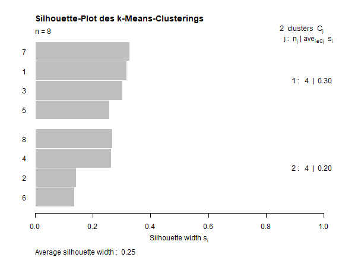

Silhouettenanalyse des k-Means-Clusterings.

```r
# 8. Silhouettenanalyse des k-Means-Ergebnisses

silhouette_result <- silhouette(
  kmeans_result$cluster,
  sample_dist
)

plot(
  silhouette_result,
  main = "Silhouette-Plot des k-Means-Clusterings"
)
```

```r
mean_silhouette <- mean(
  silhouette_result[, "sil_width"]
)

print(mean_silhouette)
```

Die mittlere Silhouettenbreite beträgt ungefähr 0,25. Damit ist die Clusterzuordnung insgesamt positiv, die Trennung jedoch nur moderat ausgeprägt. Neben dem Treatment-Effekt bleibt somit relevante Variation zwischen den Zelllinien bestehen.

# 8 Gemeinsame Diskussion und Schlussfolgerung

Die einzelnen Analyseschritte ergeben insgesamt ein konsistentes Bild. Bereits im Quality Assessment zeigen sich deutliche Unterschiede in der Library Size, sodass eine Normalisierung der Sequenziertiefe erforderlich ist. Gleichzeitig weisen die Rohcounts eine ausgeprägte Abhängigkeit der Streuung vom Expressionsniveau auf. Die VST reduziert diese Mean-Variance-Abhängigkeit und stellt damit eine geeignete Grundlage für die anschließenden explorativen Analysen bereit.

Die Differential-Expression-Analyse zeigt zahlreiche behandlungsassoziierte Expressionsänderungen. Durch das Design `~ cell + dex` wird die Variation zwischen den vier Zelllinien im statistischen Modell berücksichtigt. Die stärksten Effektgrößen werden unter anderem für `SPARCL1` in positiver und `VCAM1` in negativer Richtung beobachtet.

Auch die unüberwachten Analysen weisen auf eine deutliche Dexamethason-assoziierte Struktur hin. In der PCA ist eine Behandlungstrennung sichtbar, während gleichzeitig zelllinienspezifische Variation erhalten bleibt. t-SNE und UMAP unterstützen die explorative Betrachtung lokaler Strukturen, werden aufgrund der sehr kleinen Stichprobengröße jedoch nicht zur quantitativen Bewertung globaler Distanzen herangezogen.

Besonders deutlich zeigt sich die Behandlungsstruktur im Clustering. Complete, Average und Ward.D2 Linkage sowie k-Means mit zwei Clustern trennen behandelte und unbehandelte Proben vollständig. Diese Trennung bleibt bei Verwendung von mindestens 250 hochvariablen Genen stabil, geht bei einer Reduktion auf 100 Gene jedoch verloren. Die mittlere Silhouettenbreite von ungefähr 0,25 zeigt gleichzeitig, dass die Treatment-Cluster nicht extrem stark voneinander getrennt sind und weiterhin relevante zelllinienspezifische Variation besteht.

Insgesamt zeigen die Analysen, dass Dexamethason mit systematischen Veränderungen des Genexpressionsprofils verbunden ist, die sowohl in der differentiellen Genexpression als auch in mehreren unüberwachten Verfahren sichtbar werden. Aufgrund der kleinen Stichprobengröße von acht Samples sollten insbesondere die nichtlinearen Dimensionsreduktionsverfahren vorsichtig und primär explorativ interpretiert werden.

# 9 Nutzung von KI-Werkzeugen

Für einzelne Teile des Projekts wurden KI-Werkzeuge unterstützend eingesetzt. In Data Wrangling und Preprocessing wurde ChatGPT GPT-5.6 Luna insbesondere zur Erstellung und Korrektur von R-Syntax, zur Umsetzung einzelner Codeabschnitte sowie zur Klärung von Fragen zu R-Funktionen und Paketen verwendet. Für QA/QC wurde GPT-5.6 Luna ebenfalls unterstützend eingesetzt. Die Dimensionsreduktion wurde mit OpenAI o4-mini im TU-Braunschweig-Chatbot unterstützt. Für die Überprüfung und Korrektur des Clustering-Codes wurde stellenweise ChatGPT GPT-5.6 Sol verwendet.